# Chapter 09, Problem Set Key

### 9.1

Derive the conditions for the αs that distinguish between a stable node and an unstable point at zero (i.e., the difference between figure 9.1C and D) for the basic mutualism equations.

We know the slopes of the two isolines are $\alpha _{12}$ and $\alpha _{21}$. If they were equal, we’d have the case of exponential growth becasue the isoclines never cross. So, for coexistence to exist, we’d want one slope to be less than the other. We can write the case when they’re equal with a slope of say, $x$:

$$\begin{aligned}
\alpha _{21} &= x \\
\frac{1}{\alpha _{12}} &= x
\end{aligned}$$

For coexistence (opposed to exponential growth), one of the slopes needs to be less than $x$. Let’s say that’s sloe $\alpha _{21}$:

$$\begin{aligned}
\alpha _{21} &< x \\
\frac{1}{\alpha _{12}} &= x
\end{aligned}$$

We can substitute $x$:

$$\alpha _{21} < \frac{1}{\alpha _{12}} \text{,}$$
which shows our coexistence criterion. We can rearrange the inequality for only aesthetic reasons of putting paramters on one one side as:

$$\alpha _{12}\alpha _{21} < 1$$

This means that if the product of the mutualism coefficients is less than 1, we have coexisetnce; otherwise, we have exponential growth.

### 9.2

Modify the basic mutualism equations to model the idea of an “obligate” mutualism (defined as a population that will tend toward zero if its mutualist partner does not exist).

If a popultion without its mutualistic partner has an equilibirum value of 0, then we can set $K_i$ from the Lotka-Volterra mutaulism model to 0:

$$\begin{aligned}
\frac{\mathrm{d}N_1}{\mathrm{d}t} &= r_1N_1\left(-N_1 - \alpha _{12}N_2\right) \\
\frac{\mathrm{d}N_2}{\mathrm{d}t} &= r_2N_1\left(-N_2 - \alpha _{21}N_1\right)
\end{aligned}$$

### 9.3

The detached coefficient matrix of equation set 3 at equilibrium is
$$\begin{bmatrix}
1 & \alpha _{12} \\
\alpha _{21} & 1
\end{bmatrix}$$

Compute the determinant of this matrix (see Appendix A of chapter 2 if you need a reminder of matrix algebra), and relate it to the qualitative position of the isoclines in figure 9.2B (recall exercise 9.2).

The determinant of a $2 \times 2$ for matrix
$$\begin{bmatrix}
a & b \\
c & d
\end{bmatrix}$$

is $(1)(1) - \alpha _{12}\alpha _{21} = 1 - \alpha _{12}\alpha _{21}$.

### 9.4

What would reversing the sign of the determinant mean for the isocline graph?

Reveersing the sign of the determinant would mean that the populuation would grow. We see that in the case of 9.2C. Here, $\alpha _{12} > 1/\alpha _{21}$, meaning that $\alpha _{12}\alpha _{21} - 1 > 0$, the determinant is greater than 0, and the populations are thus growing.

### 9.5

How would you modify equation set 1 to include the logic of figure 9.5 analytically? Hint: Recall the definition of a type II functional response from chapter 6.

Equation 1 looks like:
$$\begin{aligned}
\frac{\mathrm{d}N_1}{\mathrm{d}t} &= r_1N_1\left(\frac{K_1-N_1 + \alpha _{12}N_2}{K_1}\right) \\
\frac{\mathrm{d}N_2}{\mathrm{d}t} &= r_2N_1\left(\frac{K_2-N_2 + \alpha _{21}N_1}{K_2}\right)
\end{aligned}$$

We’d then want to replace the linear functional resposes (i.e., the $\alpha _{ij}N_j$s) with the saturating Type II functional response, $c_1N_j/(g_1 + N_j)$:

$$\begin{aligned}
\frac{\mathrm{d}N_1}{\mathrm{d}t} &= r_1N_1\left(\frac{K_1 - N_1 + \frac{c_1N_2}{(g_1 + N_2)}}{K_1}\right) \\
\frac{\mathrm{d}N_2}{\mathrm{d}t} &= r_2N_1\left(\frac{K_2-N_2 + \frac{c_2N_1}{(g_2 + N_1)}}{K_2}\right)
\end{aligned}$$

### 9.6

Find the isoclines of the system derived in exercise 9.5, and plot them in the phase plane.

For $N_1$:
$$\begin{aligned}
0 &= r_1N_1\left(\frac{K_1 - N_1 + \frac{c_1N_2}{(g_1 + N_2)}}{K_1}\right) \\
N_1^{*,1} &= 0 \\
0 &= r_1\left(\frac{K_1 - N_1 + \frac{c_1N_2}{(g_1 + N_2)}}{K_1}\right) \\
0 &= r_1 - \frac{r_1N_1}{K_1} + \frac{r_1c_1N_2}{(g_1 + N_2)K_1} \\
\frac{r_1N_1}{K_1} &= r_1 + \frac{r_1c_1N_2}{(g_1 + N_2)K_1} \\
N_1^{*,2} &= K_1 + \frac{c_1N_2}{g_1 + N_2}
\end{aligned}$$

The same goes for $N_2$, but as

$$\begin{aligned}
N_2^{*,1} &= 0 \\
N_2^{*,2} &= K_2 + \frac{c_2N_1}{g_2 + N_1}
\end{aligned}$$

OK, let’s now rearrange to isolate $N_2$ for the $N_1$ isocline:

For $N_1$:
$$\begin{aligned}
N_1 &= K_1 + \frac{c_1N_2}{g_1 + N_2} \\
N_1 - K_1 &= \frac{c_1N_2}{g_1 + N_2} \\
(N_1 - K_1)(g_1 + N_2) &= c_1N_2 \\
(N_1 - K_1)g_1 + (N_1 - K_1)N_2 &= c_1N_2 \\
(N_1 - K_1)g_1 &= c_1N_2 - (N_1 - K_1)N_2 \\
(N_1 - K_1)g_1 &= (c_1 - N_1 + K_1)N_2 \\
N_2 &= \frac{(N_1 - K_1)g_1}{(c_1 - N_1 + K_1)} \\
\end{aligned}$$

OK, now in R:

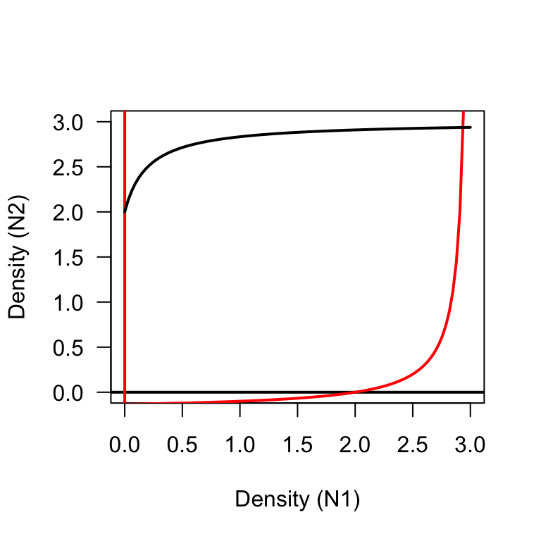

```r
max.lims <- 3
N1 <- seq(from = 0, to = max.lims, length.out = 100)

c1 <- c2 <- 1
r1 <- r2 <- 1
K1 <- K2 <- 2
g1 <- g2 <- 0.2

N1iso <- ((N1 - K1)*g1) / (c1 - N1 + K1)
N2iso <- K2 + (c2*N1)/(g2 + N1)

plot(x = NA, type = "n", xlab = "Density (N1)", ylab = "Density (N2)", xlim = c(0, max.lims), ylim = c(0, max.lims), las = 1)
  segments(x0 = -1, x1 = 5, y0 = 0, y1 = 0, lwd = 2, col = "black")
  segments(y0 = -1, y1 = 5, x0 = 0, x1 = 0, lwd = 2, col = "red")
  lines(x = N1, y = N1iso, lwd = 2, col = "red")
  lines(x = N1, y = N2iso, lwd = 2, col = "black")
```

### 9.7

Repeat the exercise in figure 9.5, but give the $N_2$ isocline the saturating feature while $N_1$ remains linear.

$$\begin{aligned}
\frac{\mathrm{d}N_1}{\mathrm{d}t} &= r_1N_1\left(\frac{K_1 - N_1 + \alpha _{12}N_2}{K_1}\right) \\
\frac{\mathrm{d}N_2}{\mathrm{d}t} &= r_2N_1\left(\frac{K_2-N_2 + \frac{c_2N_1}{(g_2 + N_1)}}{K_2}\right)
\end{aligned}$$

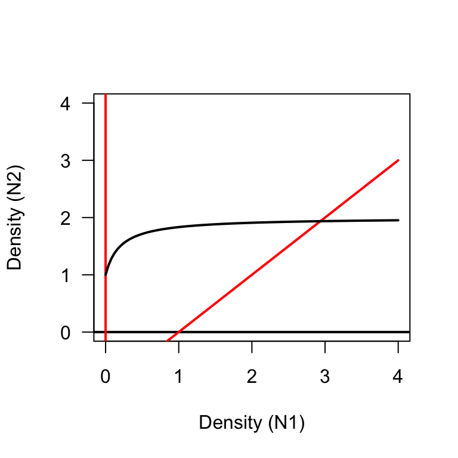

```r
max.lims <- 4
N1 <- seq(from = 0, to = max.lims, length.out = 100)

alpha12 <- 1
c2 <- 1
r1 <- r2 <- 1
K1 <- K2 <- 1
g2 <- 0.2

N1iso <- (N1 - K1) / alpha12
N2iso <- K2 + (c2*N1)/(g2 + N1)

plot(x = NA, type = "n", xlab = "Density (N1)", ylab = "Density (N2)", xlim = c(0, max.lims), ylim = c(0, max.lims), las = 1)
  segments(x0 = -1, x1 = 5, y0 = 0, y1 = 0, lwd = 2, col = "black")
  segments(y0 = -1, y1 = 5, x0 = 0, x1 = 0, lwd = 2, col = "red")
  lines(x = N1, y = N1iso, lwd = 2, col = "red")
  lines(x = N1, y = N2iso, lwd = 2, col = "black")
```

### 9.8

Modify equation set 1 to include both a mutualistic coefficient and a competition coefficient, both of which are constant. What can you conclude about the overall behavior of the system?

If we use $\beta _{ij}$ to symbolize the competition coefficient (i.e., the negative effect of speices $j$ on species $i$), we could write:

$$\begin{aligned}
\frac{\mathrm{d}N_1}{\mathrm{d}t} &= r_1N_1\left(\frac{K_1-N_1 + \alpha _{12}N_2 - \beta _{12}N_2}{K_1}\right) \\
\frac{\mathrm{d}N_2}{\mathrm{d}t} &= r_2N_1\left(\frac{K_2-N_2 + \alpha _{21}N_1 - \beta _{21}N_1}{K_2}\right)
\end{aligned}$$

We can factor $N_i$ to write:

$$\begin{aligned}
\frac{\mathrm{d}N_1}{\mathrm{d}t} &= r_1N_1\left(\frac{K_1-N_1 + (\alpha _{12} - \beta _{12})N_2}{K_1}\right) \\
\frac{\mathrm{d}N_2}{\mathrm{d}t} &= r_2N_1\left(\frac{K_2-N_2 + (\alpha _{21} - \beta _{21})N_1}{K_2}\right)
\end{aligned}$$

We can conclude that if $\beta$s are greater than $\alpha$s, then we have and overall negative interaction of one species on another. If $\beta$s are less than and $\alpha$s, then we have and overall positive interaction of one species on another.

### 9.9

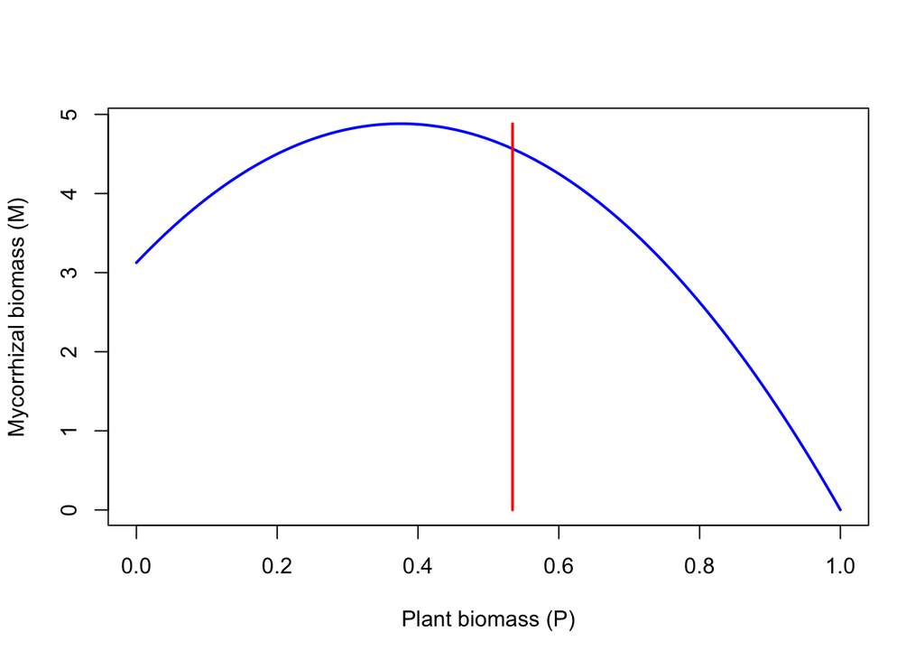

```r
P <- seq(from = 0, to = 1, length.out = 100)

g <- 0.25
alphaPM <- 0
a <- 0.08
m <- 0.0545

Miso <- (g + P*(1 - g) - P^2) / (a - alphaPM*(P + g))
Piso <- g*m/(a - m)

plot(x = P, y = Miso, col = "blue", type = "l", xlab = "Plant biomass (P)", ylab = "Mycorrhizal biomass (M)", lwd = 2)
   segments(x0 = Piso, x1 = Piso, y0 = 0, y1 = max(Miso), lwd = 2, col = "red")
```

### 9.10

Repeat exercise 9 but with αPM = 0.05. What do you conclude about the dynamics of the system, and how did adding the mutualism affect them?

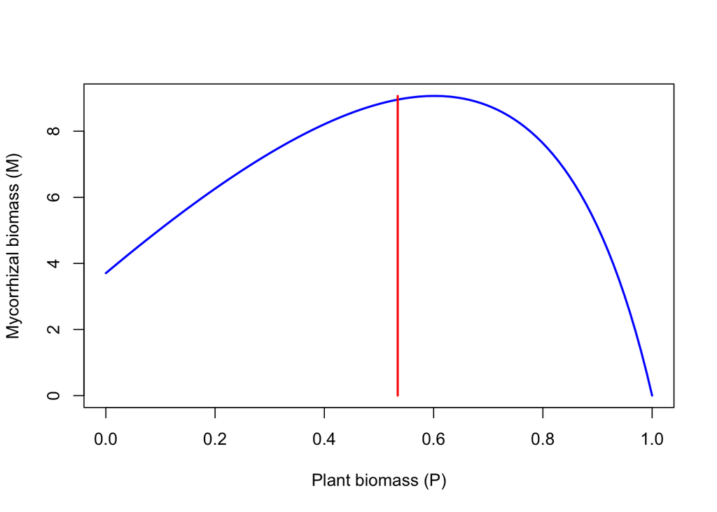

```r
P <- seq(from = 0, to = 1, length.out = 100)

g <- 0.25
alphaPM <- 0.05
a <- 0.08
m <- 0.0545

Miso <- (g + P*(1 - g) - P^2) / (a - alphaPM*(P + g))
Piso <- g*m/(a - m)

plot(x = P, y = Miso, col = "blue", type = "l", xlab = "Plant biomass (P)", ylab = "Mycorrhizal biomass (M)", lwd = 2)
   segments(x0 = Piso, x1 = Piso, y0 = 0, y1 = max(Miso), lwd = 2, col = "red")
```